# Ch 16 Excercises

# Chapter 16 Excercises

## 1

**The probability of recovery from a certain disease is 0.15. Nine people have contracted the disease. What is the probability that at most 2 of them recover? What is the expected number that will recover?**

## 3

**An airline knows that on average 10% of people making reservations on a certain flight will not show up. So they sell 20 tickets for a flight that can only hold 18 passengers.**

- **a) Assuming individual reservations are independent, what is the probability that there will be a seat available for every passenger that shows up?**

This is a Binomial Distribution, the odds that there is 1 person and 18 seats, 2 people and 18 seats….up to 18 people in 18 seats. so P(x <= 18) (out of twenty)

0.608253

- **b) Now assume there are 15 flights of this type in one evening. Let N0 be the number of these flights on which everyone who shows up gets a seat and N1 be the number of these flights that leave just one disgruntled person behind. What are the distributions of N0 and N1? What are their means and variances?**

I’m honestly not sure HOW to think of this problem…

N1 is a Negative Binomail distribution (number of success with one failure on 19 tries) * **c) The independence assumption in (a) is not really very realistic. Why? Try to describe what might be a more realistic model for this situation.**

If everyone traveled alone, then the assumption would hold. It breaks down when people travel in groups (Like a family, or business team.) a More realistic assumption would to be to figuer out the size of groups that arrive.

## 5

**A couple decides to keep having children until they have a daughter. That is, they stop when they get a daughter even if she is their first child. Let N be the number of children they have. Assume that they are equally likely to have a boy or a girl and that the sexes of their children are independent.**

- **(a). What is the distribution of N? E(N)? Var (N)?**

Negative Binomial

- **(b). Write down the probabilities that N is 1, 2, or 3.**

N(1) = 0.5 N(2) = 0.75 n(3) = 0.875

**Another couple decides to do the same thing but they don’t want an only child. That is they have two children and then only keep going if they haven’t yet had a daughter. Let M be the number of children they have.**

- **(c). Calculate P(M = 1), P(M = 2), and P(M = 3).**

P(1) DNE, it isn’t in the sample space P(2) 0.75 P(3) 0.875 * **(d). Explain why we must have P(N = i) = P(M = i) for any i ≥ 3.**

Should be fairly obvious that once they have two kids, both boys, then we back into the same sample space as the previous problem

- **(a). What is the distribution of N? E(N)? Var (N)?**
- **(b). Write down the probabilities that N is 1, 2, or 3.**

**Another couple decides to do the same thing but they don’t want an only child. That is they have two children and then only keep going if they haven’t yet had a daughter. Let M be the number of children they have.**

- **(c). Calculate P(M = 1), P(M = 2), and P(M = 3).**
- **(d). Explain why we must have P(N = i) = P(M = i) for any i ≥ 3.**

- **(e). Using the above information calculate E(M). Hint: use the known value of E(N) and consider the difference E(N) − E(M).**

## 7

**If X has a Poisson distribution and P(X = 0) = 0.2, find P(X ≥ 2)**

## 9

Factory A: store if there are two or more faulty in 10, thenstop, so p(reject) = p(X >=2)

1 - pbinom(1,10,p)

Factory B:

pbinom(0, 5, p) + pbinom(1,5,p) * pbinom(0,5,p)

**Write down an expression for the average number sampled in factory B and find its maximum value.**

5p + 1p

## 11

**A contractor rents out a piece of heavy equipment for t hours and is paid $50 per hour. The equipment tends to overheat and if it overheats x times during the hiring period, the contractor will have to pay a repair cost** $\$x^2$**. The number of times the equipment overheats in t hours can be assumed to have a Poisson distribution with mean 2t. What value of t will maximise the expected profit of the contractor?**

so lambda = 2t = y

so exp(-y)*y^x/x! is the expected overheat count so the expectation of the posion distribution is y, so y^2 is the expected cost the sales is y/2* 50 profit = 25y - y^2

the first deritavie gives us 25 -2y, set this equal to zero 2y = 25 y = 12.5 (but becuase y = 2t) we have t = 6.25

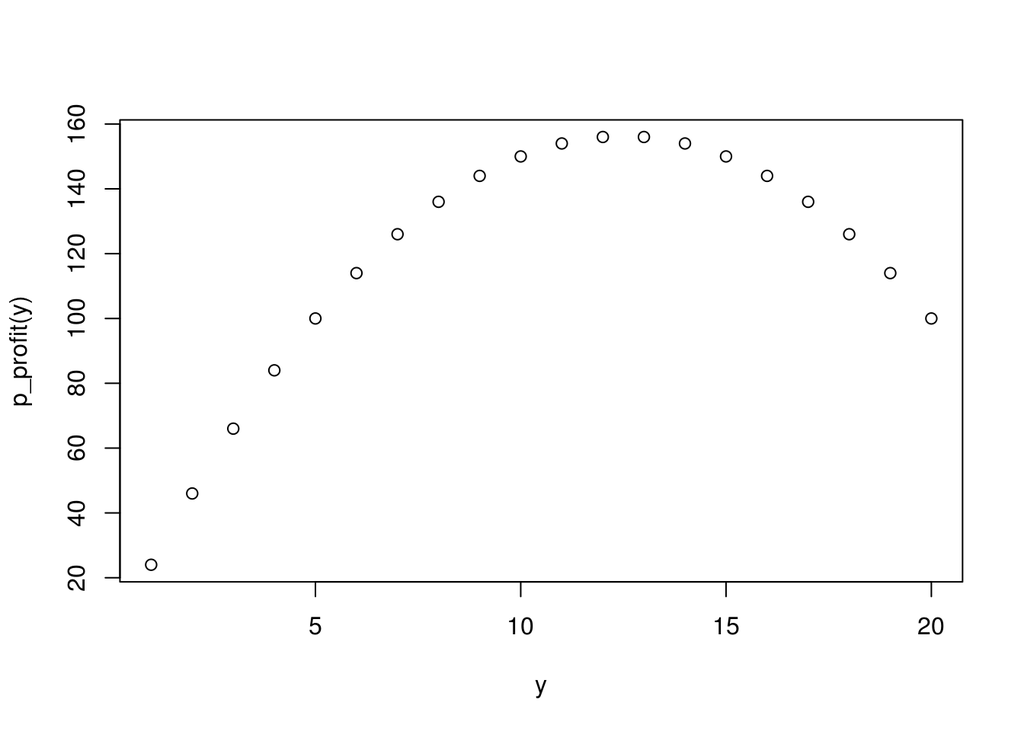

```r
p_profit = function(y){ 25*y - y^2 }
y = 1:20
x = 1
plot(y, p_profit(y) )
```

or we can do this by walking across y and x and calculating the expected outcome

```r
p_profit = function(x,y) { 25*y - (x * exp(-y)*y^(x)/factorial(x))^2 }

y = 1:20
x = 1:20

df_grid = expand.grid(x = x, y = y)
df_grid$profit = p_profit(df_grid$x, df_grid$y)

library(tidyverse)
df_grid %>% spread(x, profit, fill = 0)
```

```
##     y         1         2         3         4         5         6
## 1   1  24.86466  24.86466  24.96617  24.99624  24.99977  24.99999
## 2   2  49.92674  49.70695  49.70695  49.86976  49.96744  49.99479
## 3   3  74.97769  74.79922  74.54825  74.54825  74.74589  74.90852
## 4   4  99.99463  99.91412  99.65649  99.38931  99.38931  99.60916
## 5   5 124.99887 124.97163 124.82266 124.50738 124.23028 124.23028
## 6   6 149.99978 149.99204 149.92833 149.71334 149.35501 149.07121
## 7   7 174.99996 174.99800 174.97554 174.86684 174.59221 174.20073
## 8   8 199.99999 199.99954 199.99262 199.94755 199.79022 199.46296
## 9   9 225.00000 224.99990 224.99798 224.98179 224.90781 224.70129
## 10 10 250.00000 249.99998 249.99948 249.99427 249.96422 249.85686
## 11 11 275.00000 275.00000 274.99988 274.99834 274.98744 274.93920
## 12 12 300.00000 300.00000 299.99997 299.99955 299.99594 299.97663
## 13 13 325.00000 325.00000 324.99999 324.99988 324.99878 324.99173
## 14 14 350.00000 350.00000 350.00000 349.99997 349.99965 349.99728
```

[output cut: 48 more lines]